# linc-Brn1a KO vs WT (Adult)

This file shows the wt-v-ko comparison for linc-Brn1a.

Cuff overview:

```
## CuffSet instance with:
##   2 samples
##   26754 genes
##   77524 isoforms
##   0 TSS
##   23066 CDS
##   0 promoters
##   0 splicing
##   19954 relCDS
```

# QC

## Dispersion

Dispersion plot for genes in cuff: (Overdispersion can lead to innacurate quants)

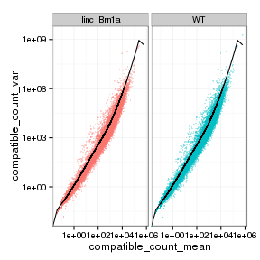

## Cross-replicate variability (fpkmSCVplot)

Differences in CV 2 can result in lower numbers of differentially expressed genes due to a higher degree of variability between replicate fpkm estimates.

Genes:

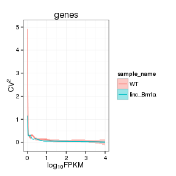

Isoforms:

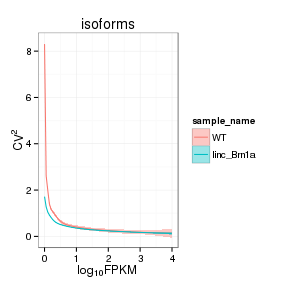

## MvA plot

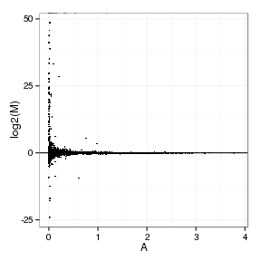

### MvA plot counts

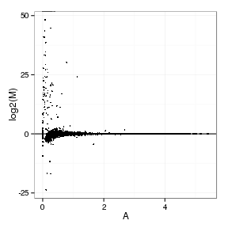

## Scatterplot matrix

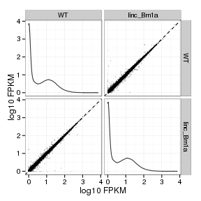

## Distributions

### Boxplots

Boxplot (genes)

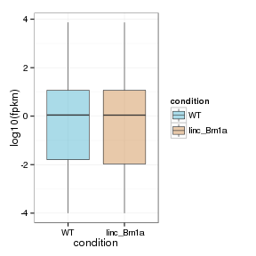

Boxplot (genes, replicates)

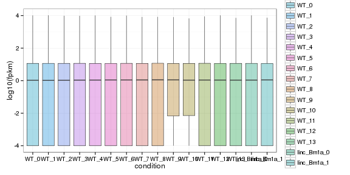

Boxplot (isoforms)

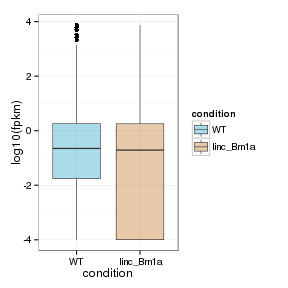

Boxplot (isoforms, replicates)

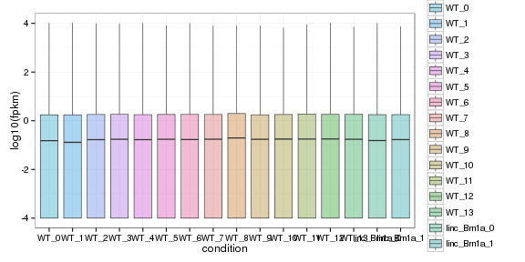

### Density

Density (genes)

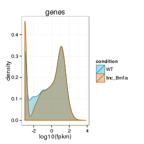

Density (genes, replicates)

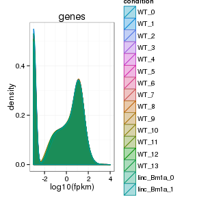

## Clustering

### Replicate Clusters

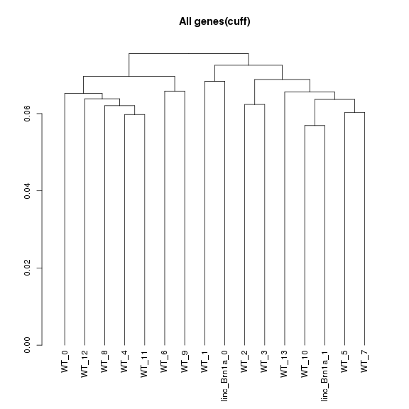

### PCA (genes)

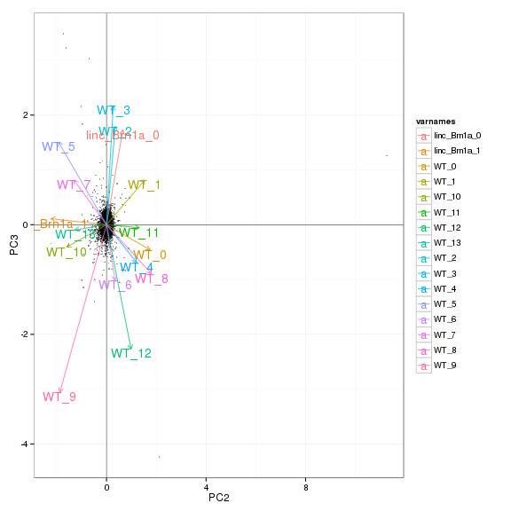

### MDS (genes)

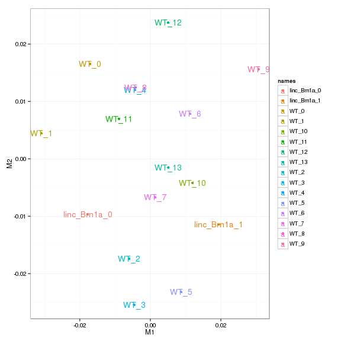

# KO assessment

## Endogenous lncRNA expression

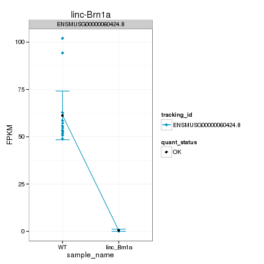

Endogenous expression of linc-Brn1a isoforms:

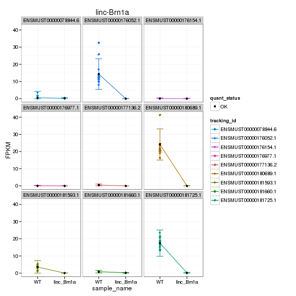

Barplot of gene expression:

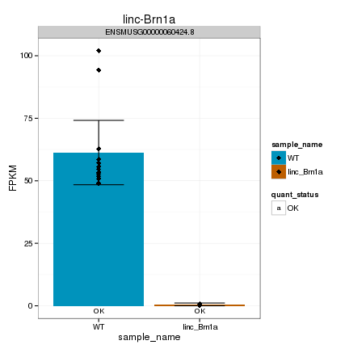

Barplot of isoform expression:

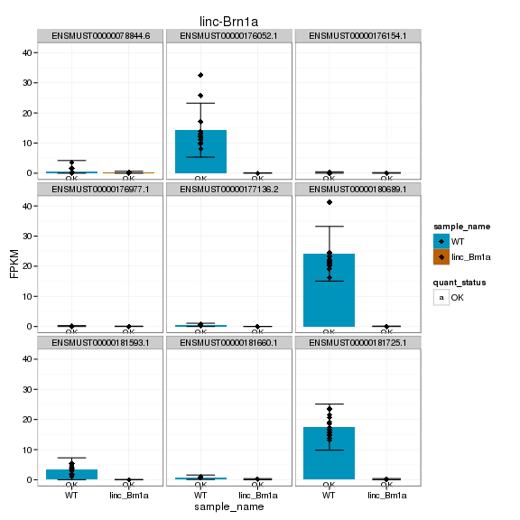

## LacZ expression

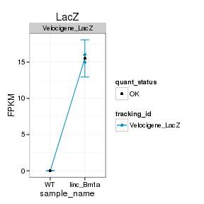

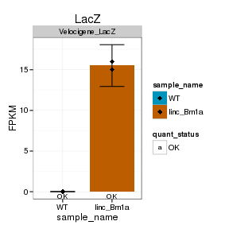

## Digital Genotyping (LacZ vs Endogenous lncRNA and Sex)

Eif2s3y is a y-expressed gene, Xist is an x-expressed gene Expression plot (endogenous linc, lacZ, Y-expressed gene):

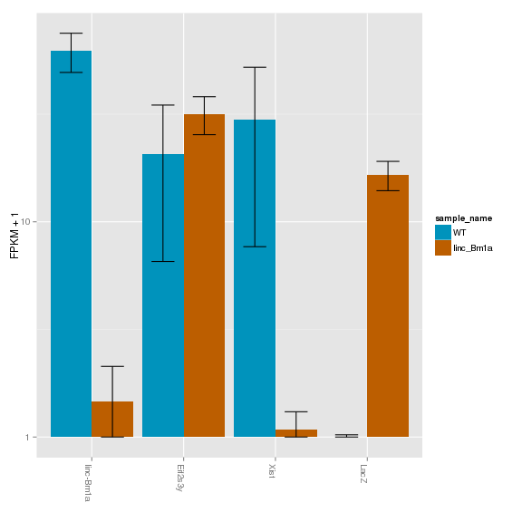

Expression heatmap:

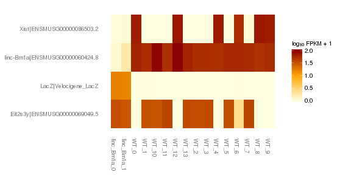

### Track visualization

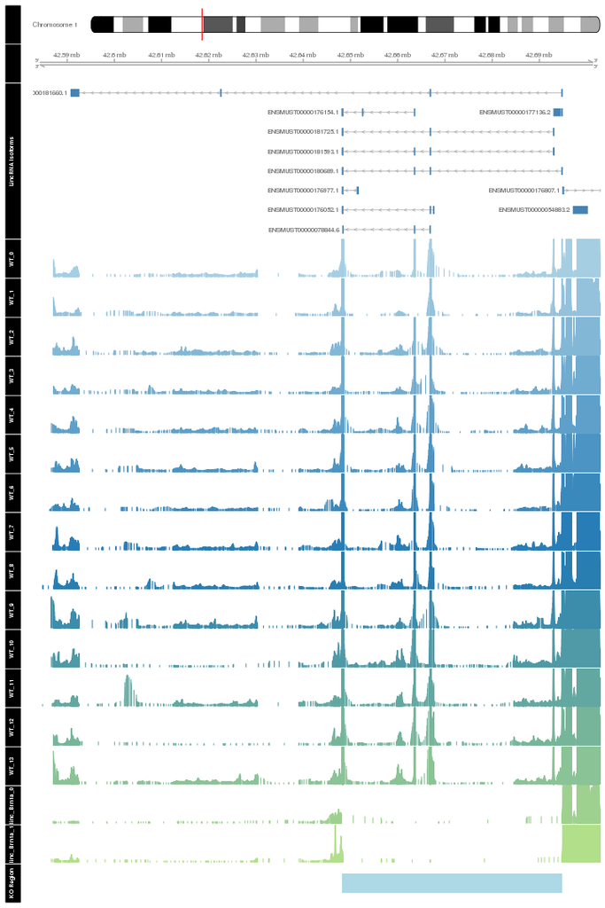

# Differential Analysis

## Differential Genes

There are 74 significantly differentially expressed genes. They are:

|  | geneAnnot$gene_short_name |
| --- | --- |
| 1 | Rec8 |
| 2 | Arrdc2 |
| 3 | Fosb |
| 4 | Dio2 |
| 5 | Mertk |
| 6 | Hspa8 |
| 7 | Vip |
| 8 | Fabp7 |
| 9 | Sgk1 |
| 10 | Mybpc1 |
| 11 | Btg2 |
| 12 | Xbp1 |
| 13 | Fos |
| 14 | Rgcc |
| 15 | Dnajc3 |
| 16 | Arc |
| 17 | Sdf2l1 |
| 18 | Nr4a1 |
| 19 | Cdkn1a |
| 20 | Sik1 |
| 21 | Xdh |
| 22 | Dusp1 |
| 23 | Fkbp5 |
| 24 | Il33 |
| 25 | Pdia4 |
| 26 | Paqr8 |
| 27 | Mcm6 |
| 28 | Tfcp2l1 |
| 29 | Hspa5 |
| 30 | Cyr61 |
| 31 | Nr4a3 |
| 32 | Alad |
| 33 | Slc2a1 |
| 34 | Mfsd2a |
| 35 | Adipor2 |
| 36 | Abcc9 |
| 37 | Pglyrp1 |
| 38 | Hddc3 |
| 39 | Tsc22d3 |
| 40 | Cryab |
| 41 | Ldlr |
| 42 | Ndn |
| 43 | Igsf9b |
| 44 | Cbl |
| 45 | Nostrin |
| 46 | Lars2 |
| 47 | Anln |
| 48 | Tob1 |
| 49 | Egr2 |
| 50 | Smim3 |
| 51 | Egr1 |
| 52 | Hdhd3 |
| 53 | Daam2 |
| 54 | Tlr7 |
| 55 | Npas4 |
| 56 | Nrros |
| 57 | Ccdc171 |
| 58 | Jun |
| 59 | Junb |
| 60 | Ier2 |
| 61 | Per2 |
| 62 | Kdm5d |
| 63 | linc-Brn1a |
| 64 | Usp31 |
| 65 | Zbtb16 |
| 66 | Ddx3y |
| 67 | Klhl9 |
| 68 | Egr4 |
| 69 | Gm7292 |
| 70 | Xist |
| 71 | Cdr1 |
| 72 | AA465934 |
| 73 | Gm6472 |
| 74 | Gm26924 |

### Matrix of gene significant differences between conditions

(skip for Brainmap wt-v-ko comparisons)

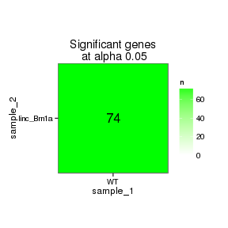

### Significant gene expression differences between conditions

Expression plot (genes):(turned off)

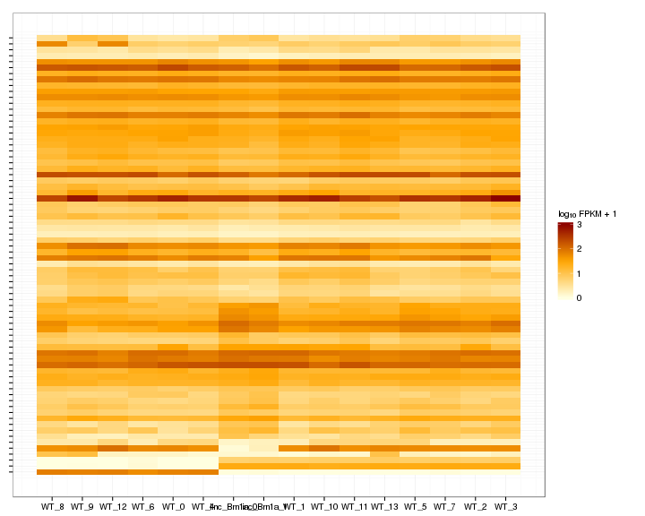

Significant genes with expression >50fpkm (any condition):(turned off)

An individual look at each of the highly expressed significantly differentially regulated genes: (eval=false for first pass)

### Expression-level/significance relationship

Scatter plot of significant genes only:

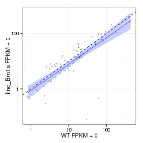

Volcano Plot

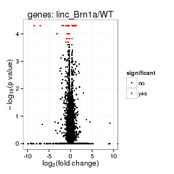

Volcano plot with significant genes only:

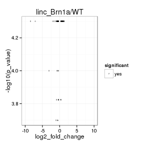

FoldChange Heatmap

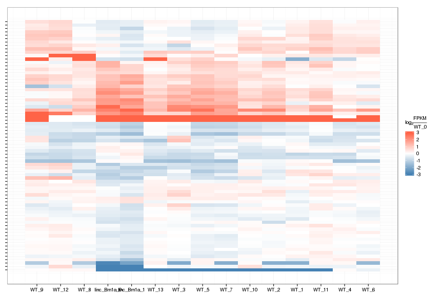